# Tutorial - SOM-based clustering

Daniel Schönberger - University of Kentucky

2024-12-28

## SOM-based species delimitation (Pyron et al. 2022, 2023)

- Use single-layer (one data matrix) or multi-layer (multiple data matrices) Kohonen Self-Organizing Maps (SOMs or SuperSOMs) to infer clusters and delimit species using unsupervised machine learning
- SOMs are used to reduce high-dimensional data into two-dimensional grid to which individuals are assigned based on their clustering of similar values across input features
- Number of clusters are chosen by k-means clustering of grid cells into proximate units based on the weighted sum of squares (WSS) of neighbor distances between adjacent cells
- Uses kohonen package (Wehrens & Buydens 2007)
- Contribution of each layer to final model output is recorded along with clustering assignment of each individual over multiple learning replicates
- Results are similar to STRUCTURE analysis including admixture estimates but represent unified delimitation model that incorporates various dimensions of ecological and evolutionary divergence for integrative taxonomy
- If only allelic data are used, then assignment probabilities approximate individual ancestry coefficients
- If multiple layers are used, assignment probabilities represent “species coefficients”
- Method is flexible and can take almost any data type as matrix or dataframe
- Each matrix needs same number of rows (representing individuals or populations) with similar rownames but each can have any number of columns (representing variables such as allele 1 or trait 1)
- Examples of input matrices: allele frequencies (biallelic SNP matrix), morphological trait data, behavioral data, spatial data (latitude, longitude, elevation), climatic data, host or habitat data, physiological data
- Data is normalized to range between 0 and 1 (if not done so already)

### Tutorial

This example code uses simple simulated data for three different datasets (allele data, environmental data and morphological data) to guide you through this SOM-based clustering approach using single-layer SOMs (each dataset alone) or using all three datasets in an integrative multi-layer Super-SOM. In all functions, I included options to change run and plotting parameters, allowing you to change the default function parameters.

### Install and load required R packages

```r
required_packages <- c("adegenet", "maps", "scales", "conStruct", "poppr", "kohonen", "lsr", "combinat", "viridis")
for (pkg in required_packages) {
  if (!requireNamespace(pkg, quietly = T)) install.packages(pkg)
  library(pkg, character.only = T)} #install missing and load packages
```

### Simulate three datasets each with 50 individuals: allele data, environmental data and morphological data

##### Specify parameters for all datasets

```r
rm(list = ls()) #clear environment
setwd("C:/Users/danie/Desktop/PhD research/Hemileuca maia research/Analyses") #set directory
set.seed(1) #set seed for reproducibility
n_individuals <- 50 #simulate dataset with n individuals (needs to be consistent across all datasets)
rownames_datasets <- "Individual" #name rows (needs to be consistent across all datasets)
```

##### Allele data (Alleles)

```r
n_Alleles <- 120 #simulate dataset with 120 alleles
allele_frequencies <- c('1' = 0.4, '0.5' = 0.25, '0' = 0.35) #set allele frequencies
Alleles <- data.frame(lapply(1:n_Alleles, function(x) sample(names(allele_frequencies), n_individuals, replace = T, prob = allele_frequencies)),
                      row.names = paste0(rownames_datasets, 1:n_individuals)) #generate Alleles based on these frequencies
Alleles[] <- lapply(Alleles, function(x) as.numeric(as.character(x))) #convert character values to numeric (0, 0.5, 1)
colnames(Alleles) <- paste("Allele", 1:n_Alleles) #rename columns as "Allele 1", "Allele 2", ..., "Allele n"
head(Alleles)
```

[output not shown]

[output cut: 85 more lines]

[output not shown]

##### Environmental data (ENV)

```r
n_env <- 38 #simulate dataset with 38 environmental variables
ENV <- matrix(runif(n_individuals * n_env, min = 0, max = 100), nrow = n_individuals, ncol = n_env)
rownames(ENV) <- paste0(rownames_datasets, 1:n_individuals)
na_indices_env <- sample(1:(n_individuals * n_env), size = round(n_individuals * n_env * 0.07), replace = F) #introduce some rare NAs for realism
colnames(ENV) <- paste("BIO", 1:n_env) #rename columns as "BIO 1", "BIO 2", ..., "BIO n"
ENV[na_indices_env] <- NA
head(ENV)
```

```
##                 BIO 1     BIO 2     BIO 3    BIO 4    BIO 5    BIO 6    BIO 7
## Individual1 77.008139 15.070790 15.008328 54.58605 62.38867       NA       NA
## Individual2 69.026253 45.462286 61.767746 32.04666 40.59831 86.64404 91.31599
## Individual3 65.047706  4.196837 99.105257 42.99886 56.50917 18.67204 56.59831
## Individual4  7.465596        NA  8.815112 56.68245 15.33809 47.62174 83.58059
## Individual5 90.258066 12.305065 71.265374 98.13158 83.08825 88.44998 31.25397
## Individual6        NA 91.338609  7.248914       NA 20.99670 79.78725 88.23542
##                 BIO 8    BIO 9   BIO 10   BIO 11    BIO 12   BIO 13   BIO 14
## Individual1 19.355473 45.49541 47.92530 73.93908 26.540488 32.79415 65.03233
## Individual2 68.863662 86.34177 14.60153       NA 62.029285 22.57601 71.83806
## Individual3 29.328654 80.41338       NA 95.10600  7.458383 24.93953 84.63536
## Individual4  7.695907 24.31971 33.57361 42.36675 54.906189 64.04880 91.16347
## Individual5  5.187354 42.63855 34.47435 19.49950        NA 65.96857 64.62323
## Individual6 52.575520 91.54632 23.35133 83.81724        NA 36.68101 39.14988
##               BIO 15    BIO 16   BIO 17    BIO 18     BIO 19   BIO 20   BIO 21
## Individual1 73.70014  1.068051 14.72765 69.587201 22.3301785 59.94539 69.86772
## Individual2 38.34754        NA 28.48760        NA 69.5393764 14.44281 45.47433
## Individual3 11.31325 62.635102 33.52183  3.859708 34.9146293 14.36768 64.71220
## Individual4 49.92936        NA 74.33374 63.851974 87.0371184 81.13782 61.37928
## Individual5 46.29826        NA 40.71536 25.135768  0.9366475 41.41423 26.64258
## Individual6 47.64756 52.102172 59.76601 33.987375 89.1871979 22.19703       NA
##               BIO 22    BIO 23    BIO 24    BIO 25    BIO 26   BIO 27   BIO 28
## Individual1 31.32603 27.840946 66.394183 95.810197 40.013152       NA       NA
## Individual2 80.28264 56.820951 66.524376 31.439710 28.660938 57.29360       NA
## Individual3 88.44504  3.294523 30.179908 20.753836  4.933831 53.30238 76.21944
## Individual4 29.05001 12.719577        NA 85.103497 13.647973 57.32317 59.77404
## Individual5 93.48389 69.069671 97.251489  4.549169  3.924404 16.01731 93.77406
## Individual6 23.48818 42.669702  9.419062 97.206564 74.494053       NA 16.47563
##                BIO 29     BIO 30     BIO 31   BIO 32   BIO 33   BIO 34   BIO 35
## Individual1 80.734799  0.3516218  0.1065846 71.61647 23.32766 90.15762 68.83148
## Individual2 64.046218 37.7068009 67.1110097 67.64684 97.68321 19.32427       NA
## Individual3  6.885538 37.1773744  9.4344703 66.39870 40.25701 97.66210       NA
## Individual4 78.895710  1.8023822 36.7147750 36.92877 54.62945 89.80741 52.65963
## Individual5 34.424713 90.6527224 75.0814827 94.20181 26.97347 58.28566 86.64051
## Individual6 65.192047 63.0890299 74.9120659 12.69057 28.42713 88.33537 20.70456
##               BIO 36   BIO 37    BIO 38
## Individual1 25.03625 60.32997 34.401174
## Individual2 40.74954 42.11311 62.449302
## Individual3 22.68189 54.28828 99.047685
## Individual4 24.90394 11.79771  1.978782
## Individual5 48.63268 79.69910 16.423091
## Individual6 30.42363 63.06702        NA
```

##### Morphological data (MORPH)

```r
n_morph <- 6 #simulate morphological data for 6 traits
MORPH <- matrix(rnorm(n_individuals * n_morph, mean = 5, sd = 2), nrow = n_individuals, ncol = n_morph) #simulate morphological data
rownames(MORPH) <- paste0(rownames_datasets, 1:n_individuals) #name rows
na_indices_morph <- sample(1:(n_individuals * n_morph), size = round(n_morph * n_individuals * 0.1), replace = F) #introduce some rare NAs for realism
MORPH[na_indices_morph] <- NA
colnames(MORPH) <- paste("Trait", 1:n_morph) #rename columns as "Trait 1", "Trait 2", ..., "Trait n"
head(MORPH)
```

```
##              Trait 1  Trait 2  Trait 3  Trait 4   Trait 5  Trait 6
## Individual1 5.258807 5.649658 5.868515 7.030841 3.5970929 6.498841
## Individual2 5.830938 6.046735 4.540272 5.656079 2.7988503 2.757111
## Individual3 7.623025 2.009195 6.098199 3.846054 0.5464719 5.885658
## Individual4 1.688583 4.880685 5.013539 7.618620 4.6306999 6.447784
## Individual5 3.888962       NA 1.498261       NA 6.0032958 3.613393
## Individual6 1.720405 3.097623 4.108988 3.238672 3.8256100 5.588066
```

### Set functions to run, evaluate and plot SOMs (based on the Github of Alex Pyron: https://github.com/rpyron)

##### Function to run single-layer SOM (one matrix)

```r
Single.Layer.SOM <- function(input_data_matrix,
                             save_SOM_results,
                             N_steps = 100,
                             N_replicates = 100,
                             N_considered_clusters = 5,
                             learning_rate_alpha_initial = 0.5,
                             learning_rate_alpha_final = 0.1,
                             missing_data_percentage = 0.9,
                             random_starts_kmeans = 25,
                             training_neighborhoods = "gaussian",
                             overwrite = T) {

  # Check if input_data_matrix is matrix, convert if not
  if (!is.matrix(input_data_matrix)) {
    message("Converting input_data_matrix to a matrix.")
    input_data_matrix <- as.matrix(input_data_matrix)} #convert to matrix if not already

  # Normalize matrix if not already normalized
  if (!(min(input_data_matrix, na.rm = T) == 0 && max(input_data_matrix, na.rm = T) == 1)) {
    input_data_matrix <- (input_data_matrix - min(input_data_matrix, na.rm = T)) / (max(input_data_matrix, na.rm = T) - min(input_data_matrix, na.rm = T))
    message(paste("Matrix normalized to the range [0, 1]."))}

  # If overwrite is FALSE and the file already exists, return saved results
  if (!overwrite && file.exists(save_SOM_results)) {
    message("SOM results already exist. Loading saved results from file and skip running this SOM model")
    load(save_SOM_results)
    return(SOM_results)}

  # Hold containers for results
  c_mat <- matrix(NA, nrow = nrow(input_data_matrix), ncol = N_replicates, dimnames = list(row.names(input_data_matrix), NULL)) #initialize c_mat as matrix
  c_mat <- as.data.frame(c_mat) #hold classifiers for SOM
  l_mat <- data.frame(row.names = 1:N_steps) #hold learning values
  w_mat <- data.frame(row.names = 1:N_considered_clusters) #hold dWSS for K

  # Create SOM output grid
  SOM_output_grid <- somgrid(xdim = round(sqrt(5 * sqrt(nrow(input_data_matrix)))),
                             ydim = round(sqrt(5 * sqrt(nrow(input_data_matrix)))),
                             topo = "hexagonal",
                             neighbourhood.fct = training_neighborhoods)

  for (j in 1:N_replicates) {

    # Train SOM model
    som_model <- som(input_data_matrix, grid = SOM_output_grid, maxNA.fraction = missing_data_percentage,
                     alpha = c(learning_rate_alpha_initial, learning_rate_alpha_final), rlen = N_steps)
    l_mat[, j] <- som_model$changes
    mydata <- getCodes(som_model) #pull codebook vectors for WSS

    # Calculate WSS for clusters
    wss <- (nrow(mydata) - 1) * sum(apply(mydata, 2, var))
    for (i in 2:(N_considered_clusters)) {wss[i] <- sum(kmeans(mydata, centers = i, nstart = random_starts_kmeans, iter.max = 1e6)$withinss)}
    N <- nrow(mydata) #sample size for BIC
    w_mat[, j] <- N * log(wss / N) + log(N) * (1:(N_considered_clusters)) #store BIC values
    if (which(w_mat[, j] == min(w_mat[, j])) == 1) {num_clusters <- 1
    } else {
      temp <- cutree(hclust(dist(diff(wss)), method = "ward.D"), k = 2)
      goodgrp <- which.min(tapply(diff(wss), temp, mean))
      num_clusters <- max(which(temp == goodgrp)) + 1}
    som_cluster <- cutree(hclust(dist(mydata)), num_clusters) #use hierarchical clustering to cluster codebook vectors
    cluster_assignment <- som_cluster[som_model$unit.classif] #get cluster assignment for each sample
    c_mat[, j] <- cluster_assignment #add cluster assignments to classifier matrix
    print(j)}

  # Save results
  call <- match.call()
  input_data_matrix_name <- as.character(call$input_data_matrix) #extract name of input data matrix using match.call
  SOM_results <- list(c_mat = c_mat, l_mat = l_mat, w_mat = w_mat, som_model = som_model,
                      som_cluster = som_cluster, cluster_assignment = cluster_assignment,
                      input_data_matrix_name = input_data_matrix_name,
                      N_steps = N_steps,
                      N_replicates = N_replicates,
                      N_considered_clusters = N_considered_clusters,
                      learning_rate_alpha_initial = learning_rate_alpha_initial,
                      learning_rate_alpha_final = learning_rate_alpha_final,
                      missing_data_percentage = missing_data_percentage,
                      random_starts_kmeans = random_starts_kmeans,
                      training_neighborhoods = training_neighborhoods)
  save(SOM_results, file = save_SOM_results)

  return(SOM_results)}


## Function to run multi-layer Super-SOM (multiple data matrices)
Multi.Layer.SOM <- function(input_data_matrices,
                            save_SOM_results,
                            N_steps = 100,
                            N_replicates = 100,
                            N_considered_clusters = 5,
                            learning_rate_alpha_initial = 0.5,
                            learning_rate_alpha_final = 0.1,
                            missing_data_percentage = 0.9,
                            random_starts_kmeans = 25,
                            training_neighborhoods = "gaussian",
                            overwrite = T) {

  # Check if all matrices have same number of rows
  num_rows <- sapply(input_data_matrices, function(mat) nrow(as.matrix(mat))) #get number of rows for each matrix
  if (length(unique(num_rows)) > 1) {stop("All input matrices must have the same number of rows. Found different row counts: ", paste(num_rows, collapse = ", "))}

  input_data_matrices <- lapply(seq_along(input_data_matrices), function(index) {
    mat <- input_data_matrices[[index]]

    # Convert to matrix if not already
    if (!is.matrix(mat)) {
      mat <- as.matrix(mat)
      message(paste("Matrix", index, "converted to matrix."))}

    # Convert to numeric if necessary
    if (!is.numeric(mat)) {
      message(paste("Matrix", index, "contains non-numeric values. Attempting to convert to numeric."))
      mat <- apply(mat, 2, as.numeric)
      if (any(is.na(mat))) {stop(paste("Matrix", index, "contains elements that cannot be converted to numeric. Please check your data."))}}
```

```r
    # Normalize matrix if not already normalized
    if (!(min(mat, na.rm = T) == 0 && max(mat, na.rm = T) == 1)) {
      mat <- (mat - min(mat, na.rm = T)) / (max(mat, na.rm = T) - min(mat, na.rm = T))
      message(paste("Matrix", index, "normalized to the range [0, 1]."))}

    return(mat)}) #end of lapply

  # Check if row names are consistent across all matrices
  if (!all(sapply(1:(length(input_data_matrices) - 1), function(i)
    identical(rownames(input_data_matrices[[i]]), rownames(input_data_matrices[[i + 1]]))))) {
    stop("Row names are not consistent across the matrices. Please provide data with matching row names!")}

  # If overwrite is FALSE and the file already exists, return saved results
  if (!overwrite && file.exists(save_SOM_results)) {
    message("SOM results already exist. Loading saved results from file and skip running this SOM model")
    load(save_SOM_results)
    return(SOM_results)}

  # Create SOM output grid
  SOM_output_grid <- somgrid(xdim = round(sqrt(5 * sqrt(length(rownames(input_data_matrices[[1]]))))),
                             ydim = round(sqrt(5 * sqrt(length(rownames(input_data_matrices[[1]]))))),
                             topo = "hexagonal",
                             neighbourhood.fct = training_neighborhoods)

  # Initialize containers for results
  c_mat <- matrix(NA, nrow = nrow(input_data_matrices[[1]]), ncol = N_replicates, dimnames = list(row.names(input_data_matrices[[1]]), NULL)) #initialize c_mat as matrix
  c_mat <- data.frame(row.names = row.names(input_data_matrices[[1]])) #hold classifiers for DNAsom
  d_mat <- data.frame(matrix(NA, nrow = N_replicates, ncol = length(input_data_matrices))) #distance weights
  l_mats <- lapply(1:length(input_data_matrices), function(i) data.frame(row.names = 1:N_steps)) #learning values
  w_mat <- data.frame(row.names = 1:N_considered_clusters) #dWSS for K

  for (j in 1:N_replicates) { #train SOMs
    som_model <- supersom(data = input_data_matrices, grid = SOM_output_grid, maxNA.fraction = missing_data_percentage,
                          alpha = c(learning_rate_alpha_initial, learning_rate_alpha_final), rlen = N_steps) #create SOM model
    for (i in seq_along(input_data_matrices)) {l_mats[[i]][, j] <- som_model$changes[, i]} #store learning values for each matrix
    d_mat[j, ] <- som_model$distance.weights #store distance weights

    # Calculate within-cluster sum of squares (WSS) for each cluster
    mydata <- do.call(cbind, lapply(1:length(input_data_matrices), function(i) getCodes(som_model)[[i]]))
    wss <- numeric(N_considered_clusters)
    wss[1] <- (nrow(mydata) - 1) * sum(apply(mydata, 2, var))
    for (i in 2:N_considered_clusters) {wss[i] <- sum(kmeans(mydata, centers = i, nstart = random_starts_kmeans, iter.max = 1e6)$withinss)}

    # Calculate BIC for each cluster using WSS
    sample_size_BIC <- dim(mydata)[1]
    w_mat[, j] <- sample_size_BIC * log(wss / sample_size_BIC) + log(sample_size_BIC) * (1:N_considered_clusters)

    # Determine optimal number of clusters using hierarchical clustering based on WSS values
    if (which(w_mat[, j] == min(w_mat[, j])) == 1) {num_clusters <- 1
    } else {
      temp <- cutree(hclust(dist(diff(wss)), method = "ward.D"), k = 2)
      goodgrp <- which.min(tapply(diff(wss), temp, mean))
      num_clusters <- max(which(temp == goodgrp)) + 1}

    som_cluster <- cutree(hclust(dist(mydata)), num_clusters) #perform hierarchical clustering to assign clusters
    cluster_assignment <- som_cluster[som_model$unit.classif]
    c_mat[, j] <- cluster_assignment #store cluster assignments
    print(j)}

  # Save results
  call <- match.call()
  input_data_matrices_names <- as.character(call$input_data_matrices)
  SOM_results <- list(c_mat = c_mat, d_mat = d_mat, l_mats = l_mats, w_mat = w_mat, som_model = som_model,
                      som_cluster = som_cluster, cluster_assignment = cluster_assignment,
                      input_data_matrices_names = input_data_matrices_names[-1],
                      N_steps = N_steps,
                      N_replicates = N_replicates,
                      N_considered_clusters = N_considered_clusters,
                      learning_rate_alpha_initial = learning_rate_alpha_initial,
                      learning_rate_alpha_final = learning_rate_alpha_final,
                      missing_data_percentage = missing_data_percentage,
                      random_starts_kmeans = random_starts_kmeans,
                      training_neighborhoods = training_neighborhoods)
  save(SOM_results, file = save_SOM_results)

  return(SOM_results)}


## Function to plot learning progress for each SOM matrix
plot.Learning.SOM <- function(SOM_output,
                              color_palette = viridis::turbo,
                              alpha_lines = 0.3,
                              save_svg = F,
                              svg_filename,
                              svg_width = 7 / 2.54,
                              svg_height = 5 / 2.54,
                              margin_bottom = 6,
                              margin_left = margin_bottom,
                              margin_top = 3,
                              margin_right = 2) {

  # Check if l_mat or l_mats exists and is either matrix or list
  if ("l_mat" %in% names(SOM_output)) {SOM_output$l_mats <- list(SOM_output$l_mat) #convert to list for single-layer case
  } else if ("l_mats" %in% names(SOM_output)) { #multi-layer case
  } else {stop("Neither l_mat nor l_mats found in SOM_output.")}
  if (!is.list(SOM_output$l_mats)) {stop("SOM_output$l_mats is not a list.")} #check if l_mats is list

  # Convert data.frames to matrices if necessary
  SOM_output$l_mats <- lapply(SOM_output$l_mats, function(x) {
    if (is.data.frame(x)) {return(as.matrix(x))} #convert data.frame to matrix
    return(x)})

  # Ensure all elements in l_mats are matrices
  if (!all(sapply(SOM_output$l_mats, is.matrix))) {stop("SOM_output$l_mats contains non-matrix elements after conversion.")}
```

```r
  # Extract matrix names (check for multi-layer or single-layer)
  if ("input_data_matrix_name" %in% names(SOM_output)) {matrix_names <- list(SOM_output$input_data_matrix_name) #single-layer case
  } else if ("input_data_matrices_names" %in% names(SOM_output)) {matrix_names <- SOM_output$input_data_matrices_names #multi-layer case
  } else {stop("Matrix names not found in provided SOM_output.")}

  # Validate matrix names
  if (length(matrix_names) != length(SOM_output$l_mats)) {stop("The number of matrix names does not match the number of matrices.")}

  # Determine global ylim
  global_ylim <- range(unlist(lapply(SOM_output$l_mats, function(mat)
    range(mat, na.rm = T))), na.rm = T) * c(0.9, 1.1) #expand range slightly

  # Prepare base plot
  first_matrix <- SOM_output$l_mats[[1]] #first matrix for xlim
  par(mfrow = c(1, 1), mar = c(margin_bottom, margin_left, margin_top, margin_right))
  plot(NULL, xlim = c(1, nrow(first_matrix)), ylim = global_ylim, xlab = "Training steps",
       ylab = "Learning rate change", main = "Training progress across layer(s)", axes = T)

  # Plot each matrix
  layer_colors <- color_palette(length(SOM_output$l_mats)) #use dynamic colors
  for (i in seq_along(SOM_output$l_mats)) {mat <- SOM_output$l_mats[[i]]
  for (j in 1:ncol(mat))
    lines(mat[, j], col = alpha(layer_colors[i], alpha_lines))} #plot lines
  legend("topright", legend = matrix_names, col = layer_colors, lty = 1, cex = 0.8, title = "Layers") #add legend

  # Save as SVG if requested
  if (save_svg) {
    svg(svg_filename, width = svg_width, height = svg_height) #open SVG device
    plot(NULL, xlim = c(1, nrow(first_matrix)), ylim = global_ylim, xlab = "Training steps",
         ylab = "Learning rate change", main = "Training progress across layer(s)", axes = T) #recreate plot
    for (i in seq_along(SOM_output$l_mats)) {mat <- SOM_output$l_mats[[i]]
    for (j in 1:ncol(mat))
      lines(mat[, j], col = alpha(layer_colors[i], alpha_lines))} #add lines
    legend("topright", legend = matrix_names, col = layer_colors, lty = 1, cex = 0.8, title = "Layers")
    dev.off()}}


## Function to plot layer weights
plot.Layers.SOM <- function(SOM_output, color_palette = viridis::turbo) {

  # Check if 'd_mat' exists in SOM_output
  if (!"d_mat" %in% names(SOM_output)) {
    message("Single-layer SOM detected. No layers to plot.")
    return(invisible(NULL))} #skip plotting for single-layer SOM

  d_mat <- SOM_output$d_mat #extract distance matrix
  layer_names <- SOM_output$input_data_matrices_names #extract layer names, excluding "list" placeholder

  # Validate that names match number of layers
  if (length(layer_names) != ncol(d_mat)) {
    message("Mismatch detected. Using generic layer names.")
    layer_names <- paste0("Matrix ", seq_len(ncol(d_mat)))}

  # Calculate relative layer weights
  raw_weights <- sqrt(1 / colMeans(d_mat)) #compute weights
  names(raw_weights) <- layer_names #assign names to weights
  sorted_weights <- sort(raw_weights, decreasing = T) #sort weights for better visualization

  # Plot layer weights with proper labels and colors
  layer.cols <- setNames(color_palette(length(layer_names)), layer_names) #assign colors to matrix names
  par(mfrow = c(1, 1))
  barplot(sorted_weights, main = "Layer weights", col = layer.cols[names(sorted_weights)], names.arg = names(sorted_weights), ylab = "Relative weights (sqrt(1/w))")}


## Function to evaluate K-values
plot.K.SOM <- function(SOM_output, color_palette = viridis::magma) {

  # Prepare data
  w_mat <- SOM_output$w_mat #extract BIC matrix from SOM output
  max_clusters <- nrow(w_mat) #determine maximum number of clusters considered
  k.cols <- color_palette(max_clusters) #generate color palette with enough colors for each cluster

  #Set up plotting area and adjust margins
  par(mfrow = c(3, 1), mar = c(0.5, 4, 1, 0.5))

  # Create boxplot for BIC values
  boxplot(t(w_mat), outline = F, notch = F, axes = F, ylab = "BIC", ylim = range(unlist(w_mat)), col = k.cols)
  axis(1, at = 1:max_clusters, labels = NA)
  axis(2, at = round(range(unlist(w_mat))), las = 3)
  title("Number of clusters (k)", line = 0)

  # Create boxplot for delta BIC
  d_wss <- apply(w_mat, 2, function(x) diff(diff(x)))
  boxplot(t(d_wss), outline = F, notch = F, axes = F, ylab = "Delta BIC", col = k.cols)
  abline(h = 0, lty = 2, col = "black")
  axis(1, at = 1:(max_clusters - 2), labels = NA)
  axis(2, at = sort(c(0, round(range(unlist(d_wss))))), las = 3)

  ## Create barplot for sampling frequency of cluster counts
  par(mar = c(4, 4, 1, 0.5))
  all_k <- apply(SOM_output$c_mat, 2, max)
  barplot(table(factor(all_k, levels = 1:max_clusters)) / SOM_output$N_replicates, ylab = "Sampling frequency", ylim = c(0, 1), col = k.cols)}


## Function to get and synchronize labels for different K values and summarize across K for Qmat
match.k.and.labels.SOM <- function(SOM_output) {

  # Handle input_data_matrix_1 based on SOM_output$l_mats
  if (length(SOM_output$som_model$codes) == 1) {input_data_matrix_1 <- get(SOM_output$input_data_matrix_name, envir = .GlobalEnv)
  } else {input_data_matrix_1 <- get(SOM_output$input_data_matrices_names[1], envir = .GlobalEnv)}

  # Replace NA values with 0.5 in input_data_matrix_1
  if (any(is.na(input_data_matrix_1))) {input_data_matrix_1[which(is.na(input_data_matrix_1))] <- 0.5}

  # Preprocess input data and generate cluster labels
  input_data_matrix_1_new <- input_data_matrix_1
  cluster_labels <- rbind.data.frame(lapply(1:SOM_output$N_considered_clusters, function(x) {kmeans(input_data_matrix_1_new, x)$cluster})) #run k-means for each K and store cluster labels
  rownames(cluster_labels) <- rownames(input_data_matrix_1) #set row names for cluster labels
  colnames(cluster_labels) <- paste("K", 1:SOM_output$N_considered_clusters, sep = '') #set column names

  # Extract SOM cluster assignments and filter replicates based on maximum K
  c_mat <- SOM_output$c_mat #extract cluster assignments matrix from SOM output
  if (ncol(c_mat) != SOM_output$N_replicates) {stop("The number of columns in SOM_output$c_mat does not match N_replicates. Please check.")}
  all_k <- apply(c_mat, 2, max) #calculate maximum K for each replicate (column)
  cc <- c_mat[, which(all_k <= SOM_output$N_considered_clusters)] #filter to keep replicates with K <= N_considered_clusters
```

```r
  # Relabel across replicates
  cca <- cc #create copy of filtered matrix for relabeling
  for (i in 1:SOM_output$N_replicates) {
    run.k <- max(cca[, i]) #get number of clusters (K) for current replicate
    run.labels <- as.numeric(cluster_labels[, run.k]) #get corresponding labels for current K
    refactor <- data.frame(row.names = rownames(cluster_labels)) #create dataframe to store relabelings
    label.perm <- permn(1:run.k) #generate all permutations of labels
    for (j in 1:length(label.perm)) {refactor[, j] <- cca[, i]} #apply label permutations and calculate best matching relabeling
    for (k in 1:length(label.perm)) {refactor[, k] <- as.numeric(permuteLevels(factor(refactor[, k]), perm = label.perm[[k]]))} #relabel using permutations
    cc[, i] <- refactor[, which.min(apply(refactor, 2, function(x) {sum(abs(x - run.labels))}))]} #choose relabeling that minimizes distance to original labels

  # Calculate Q-matrix (admixture matrix) summarizing cluster memberships and return it
  q_mat <- t(apply(cc, 1, FUN = function(x) {table(factor(unlist(x), levels = 1:max(all_k)))}) / dim(cca)[2]) #create table for cluster assignments and normalize it by number of replicates
  SOM_output$q_mat <- q_mat #add q_mat to SOM_output
  SOM_output$input_data_matrix_1 <- input_data_matrix_1
  return(SOM_output)}


## Function to plot model results as SOM grids (showing sample assignment to cells, cell distances and boundaries between cell clusters)
plot.Model.SOM <- function(SOM_output,
                           color_palette_SOM_neighbour_distances = viridis::cividis,
                           color_palette_SOM_cluster = viridis::viridis,
                           boundary_color = "red",
                           sample_color = "white",
                           sample_shape = 19,
                           margin_top = 1.5,
                           margin_bottom = 1,
                           margin_left = 1,
                           margin_right = 1) {

  # Convert input_data_matrix_1 to consistent numeric matrix format
  if (is.data.frame(SOM_output$input_data_matrix_1)) {
    SOM_output$input_data_matrix_1 <- as.matrix(
      sapply(SOM_output$input_data_matrix_1, as.numeric)) #convert each column to numeric
  } else if (is.list(SOM_output$input_data_matrix_1)) {SOM_output$input_data_matrix_1 <- do.call(cbind, SOM_output$input_data_matrix_1) #combine list elements into matrix
  } else if (is.matrix(SOM_output$input_data_matrix_1) || inherits(SOM_output$input_data_matrix_1, "array")) {
    SOM_output$input_data_matrix_1 <- as.matrix(SOM_output$input_data_matrix_1) #ensure it is a matrix
  } else {stop("Unsupported data format for input_data_matrix_1. Must be a data frame, list or matrix")}

  # Check for NA, NaN, or Inf values
  if (any(is.na(SOM_output$input_data_matrix_1))) {warning("NA values detected. Replacing with column means.")
    if (any(is.na(SOM_output$input_data_matrix_1))) { #replace NA values in matrix with column means
      col_means <- apply(SOM_output$input_data_matrix_1, 2, mean, na.rm = T) #calculate column means
      for (j in seq_len(ncol(SOM_output$input_data_matrix_1))) {SOM_output$input_data_matrix_1[is.na(SOM_output$input_data_matrix_1[, j]), j] <- col_means[j]}}} #loop through each column
  if (any(is.infinite(SOM_output$input_data_matrix_1))) {stop("input_data_matrix_1 contains Inf/-Inf values. Replace or remove them.")}

  # Ensure input is numeric
  if (!is.numeric(as.matrix(SOM_output$input_data_matrix_1))) {stop("input_data_matrix_1 must be numeric. Check the data and convert if necessary.")}

  # Remove zero variance columns
  zero_var_cols <- apply(SOM_output$input_data_matrix_1, 2, var) == 0
  if (any(zero_var_cols)) {
    warning("Removing columns with zero variance.")
    SOM_output$input_data_matrix_1 <- SOM_output$input_data_matrix_1[, !zero_var_cols]}

  # Ensure cluster numbers are valid
  if (SOM_output$N_considered_clusters > nrow(SOM_output$input_data_matrix_1)) {stop("N_considered_clusters exceeds the number of rows in input_data_matrix_1.")}

  # Generate Cluster Labels
  cluster_labels <- rbind.data.frame(lapply(1:SOM_output$N_considered_clusters, function(x) { #preprocess input data and generate cluster labels using k-means
    kmeans(SOM_output$input_data_matrix_1, x)$cluster})) #run k-means for each K and store cluster labels
  rownames(cluster_labels) <- rownames(SOM_output$input_data_matrix_1)
  colnames(cluster_labels) <- paste("K", 1:SOM_output$N_considered_clusters, sep = '')

  # Plot SOM Neighbour Distances
  par(mfrow = c(2, 1), mar = c(margin_bottom, margin_left, margin_top, margin_right))
  plot(SOM_output$som_model, type = "dist.neighbours", main = "", palette.name = color_palette_SOM_neighbour_distances)
  title("SOM neighbour distances", line = 0)

  # Relabel SOM Clusters and Plot
  run.k <- max(SOM_output$som_cluster) #get inferred cluster number from SOM output
  message("Inferred number of clusters (K): ", run.k)
  run.labels <- as.numeric(cluster_labels[, run.k]) #pull DAPC labels matching current K
  refactor <- data.frame(row.names = rownames(cluster_labels))

  # Generate all label permutations for the current K and apply them
  label.perm <- permn(1:run.k)
  for (j in 1:length(label.perm)) {refactor[, j] <- SOM_output$cluster_assignment}
  for (k in 1:length(label.perm)) {refactor[, k] <- as.numeric(permuteLevels(factor(refactor[, k]), perm = label.perm[[k]]))}
  run.labels <- refactor[, which.min(apply(refactor, 2, function(x) {sum(abs(x - run.labels))}))] #select relabeling that minimizes distance to original labels by calculating sum of absolute differences

  ## Generate Colors
  k.cols <- color_palette_SOM_cluster(run.k) #use inferred number of clusters (run.k) for length of k.cols palette
  som.cols <- run.labels #assign colors to SOM clusters using relabeled cluster assignments
  som.cols <- setNames(som.cols, SOM_output$cluster_assignment) #assign color labels to SOM clusters
  som.cols <- unique(som.cols[sort(names(som.cols))]) #set to refactored labels
```

```r
  # Plot SOM clusters
  plot(SOM_output$som_model, shape = "straight", type = "mapping", bgcol = k.cols[som.cols][SOM_output$som_cluster], main = "", pch = sample_shape, col = sample_color)
  if (run.k > 1) {add.cluster.boundaries(SOM_output$som_model, SOM_output$som_cluster, col = boundary_color)} #add boundaries around SOM clusters for k > 1
  title("SOM clusters", line = 0)}


## Function to plot variable importance for each SOM matrix (based on Codebook Vectors/Neuron Weights)
variable.importance.SOM <- function(SOM_output,
                                    color_palette_plot = viridis::turbo,
                                    bars_threshold_N = 50,
                                    left_margin_plot = 8.5,
                                    all_margins_plot = 3,
                                    title_font_size = 1.2,
                                    many_label_font_size = 21) {

  # Extract SOM codes
  codes <- SOM_output$som_model$codes
  n_matrices <- length(codes)
  m.codes <- lapply(codes, function(x) apply(x, 2, median)) #calculate median for each column in each matrix

  # Extract matrix names from SOM_output
  if ("input_data_matrix_name" %in% names(SOM_output)) {matrix_names <- list(SOM_output$input_data_matrix_name) #single-layer case
  } else if ("input_data_matrices_names" %in% names(SOM_output)) {matrix_names <- SOM_output$input_data_matrices_names #multi-layer case
  } else {stop("Matrix names not found in provided SOM_output.")}

  # Iterate over each matrix and generate plots
  for (i in seq_along(m.codes)) {

    # Extract sorted data and corresponding labels
    sorted_data <- sort(m.codes[[i]][which(m.codes[[i]] > 0.001)])
    y_labels <- names(sorted_data)
    num_bars <- length(sorted_data) #number of bars

    # Dynamically adjust label size or suppress labels
    if (num_bars > bars_threshold_N) {
      y_labels <- rep("", num_bars) #suppress y-axis labels
      label_size <- 1 #default size when labels are suppressed
      margins <- c(all_margins_plot, all_margins_plot, all_margins_plot, all_margins_plot) #margins for suppressed labels
      message(paste("Matrix", i, "has too many bars. Y-axis labels are suppressed. Increase bars_threshold_N to show labels"))
    } else {
      label_size <- ifelse(num_bars <= 10, 1, many_label_font_size / num_bars)
      margins <- c(all_margins_plot, left_margin_plot, all_margins_plot, all_margins_plot)} #standard margin for visible labels

    # Barplot for current matrix
    layer.cols <- color_palette_plot(n_matrices) #define colors using viridis palette
    par(mar = margins, mfrow = c(1, 1)) #set margins and plotting parameters
    barplot(sorted_data, horiz = T, las = 1, col = layer.cols[i], xlim = c(0, 1), names.arg = y_labels, cex.names = label_size)
    mtext(paste("Variable importance -", matrix_names[[i]]), side = 3, line = 1, cex = title_font_size, font = 2)} #adjust title size

  return(m.codes)} #return computed median values


## Function to plot Structure-like barplots
plot.structure.SOM <- function(SOM_output,
                               linkage_method = "single",
                               csv_filename_admixture_proportions,
                               color_palette = viridis::viridis,
                               margin_top = 2,
                               margin_bottom = 9.5,
                               margin_left = 4,
                               margin_right = 2,
                               sort_by_col = 1,
                               save_csv = T,
                               overwrite = T) {

  # Ensure input is valid
  if (is.null(SOM_output$q_mat) || !is.matrix(SOM_output$q_mat)) {stop("Input 'SOM_output$q_mat' must be a non-null matrix.")}

  # Order rows of SOM_output$q_mat based on values in the specified column
  admixture_proportions <- SOM_output$q_mat[order(SOM_output$q_mat[, sort_by_col]), ]

  # If there's only one cluster, no need for clustering or sorting
  if (nrow(SOM_output$q_mat) == 1) {
    cat("Only one cluster detected, skipping structure plot.\n")
    SOM_admixture_proportions <- SOM_output$q_mat  # No change needed
  } else {

  # Perform hierarchical clustering on distance matrix
  cluster_order <- hclust(dist(admixture_proportions), method = linkage_method)$order
  SOM_admixture_proportions <- admixture_proportions[cluster_order, ]

  # Save to CSV if save_csv is TRUE
  if (save_csv) {
    if (file.exists(csv_filename_admixture_proportions)) { #check if file exists
      if (overwrite) {
        write.csv(SOM_admixture_proportions, file = csv_filename_admixture_proportions, row.names = T)
        message(paste("SOM admixture proportions overwritten and saved to", csv_filename_admixture_proportions))
      } else {message(paste("File", csv_filename_admixture_proportions, "already exists. Set overwrite = TRUE to overwrite file"))}
    } else {
      write.csv(SOM_admixture_proportions, file = csv_filename_admixture_proportions, row.names = T)
      message(paste("SOM admixture proportions saved to", csv_filename_admixture_proportions))}}

  # Plot Structure-like barplot
  layer_colors <- color_palette(ncol(SOM_admixture_proportions)) #generate layer colors
  par(mfrow = c(1, 1))
  make.structure.plot(admix.proportions = SOM_admixture_proportions, sample.names = rownames(SOM_admixture_proportions),
                      mar = c(margin_bottom, margin_left, margin_top, margin_right),
                      layer.colors = layer_colors, sort.by = sort_by_col)}}
```

### Run SOMs, and evaluate and plot SOM results

##### Specify parameters for SOM runs

```r
SOM_steps <- 100 #number of steps
SOM_replicates <- 100 #number of replicates for SOM method
SOM_clusters <- 12 #max number of considered clusters
```

##### Run single-layer and multi-layer SOMs

```r
SOM_Alleles <- Single.Layer.SOM(input_data_matrix = Alleles, N_replicates = SOM_replicates,
                                N_steps = SOM_steps, N_considered_clusters = SOM_clusters, save_SOM_results = "SOM_results_Alleles.RData")
```

```
## Converting input_data_matrix to a matrix.
```

[output not shown]

[output cut: 85 more lines]

```r
SOM_ENV <- Single.Layer.SOM(input_data_matrix = ENV, N_replicates = SOM_replicates,
                            N_steps = SOM_steps, N_considered_clusters = SOM_clusters, save_SOM_results = "SOM_results_ENV.RData")
```

```
## Matrix normalized to the range [0, 1].
```

[output not shown]

[output cut: 85 more lines]

```r
SOM_MORPH <- Single.Layer.SOM(input_data_matrix = MORPH, N_replicates = SOM_replicates,
                              N_steps = SOM_steps, N_considered_clusters = SOM_clusters, save_SOM_results = "SOM_results_MORPH.RData")
```

```
## Matrix normalized to the range [0, 1].
```

[output not shown]

[output cut: 85 more lines]

```r
SOM_Alleles_ENV_MORPH <- Multi.Layer.SOM(input_data_matrices = list(Alleles, ENV, MORPH),
                                         N_replicates = SOM_replicates, N_steps = SOM_steps,
                                         N_considered_clusters = SOM_clusters, save_SOM_results = "SOM_results_Alleles_ENV_MORPH.RData")
```

```
## Matrix 1 converted to matrix.
```

```
## Matrix 2 normalized to the range [0, 1].
```

```
## Matrix 3 normalized to the range [0, 1].
```

[output not shown]

[output cut: 85 more lines]

##### Plot learning progress for each SOM matrix

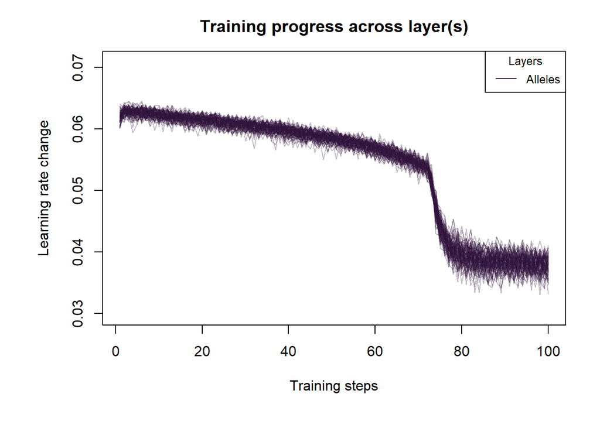

```r
plot.Learning.SOM(SOM_Alleles)
```

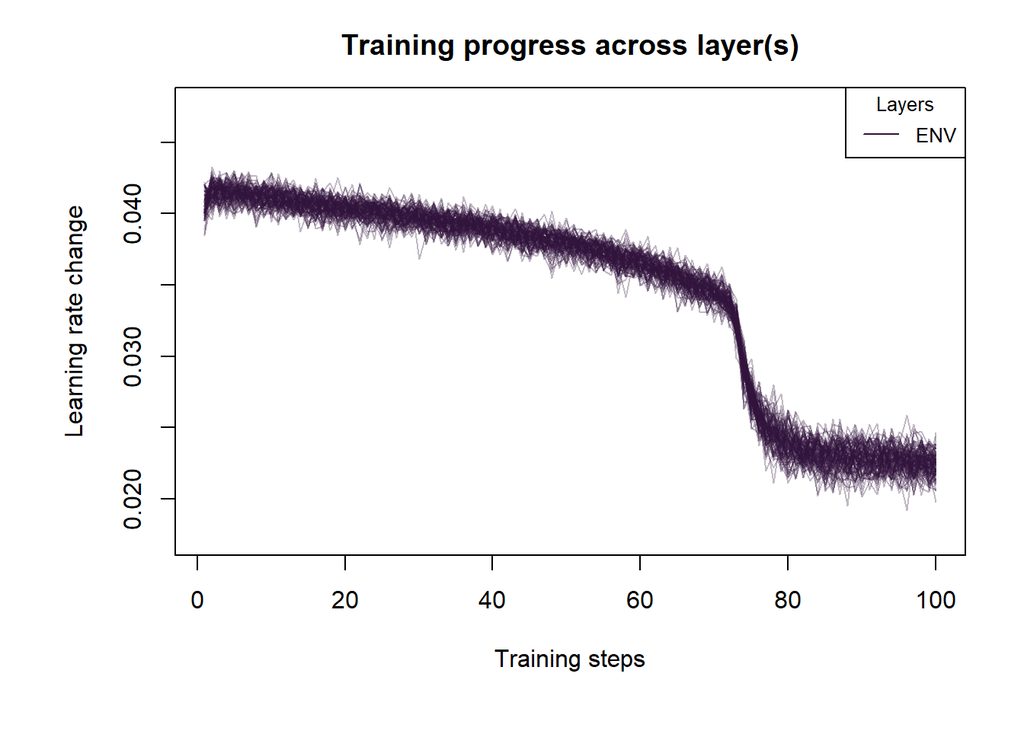

```r
plot.Learning.SOM(SOM_ENV)
```

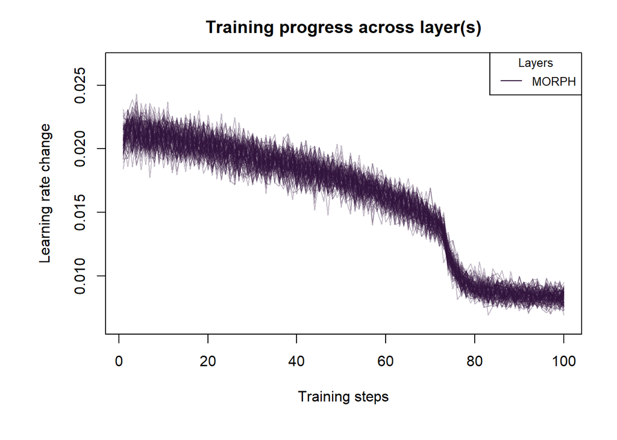

```r
plot.Learning.SOM(SOM_MORPH)
```

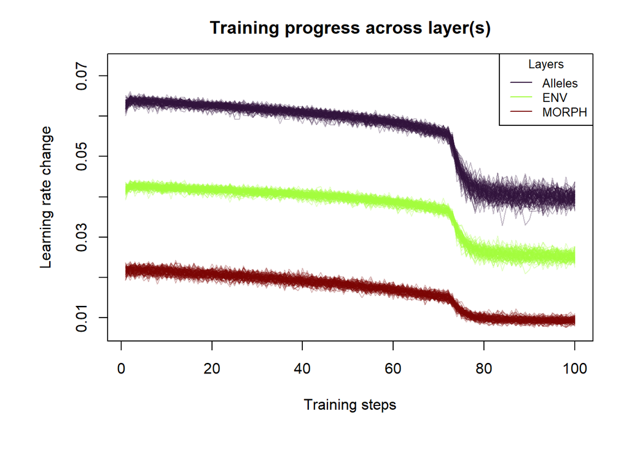

```r
plot.Learning.SOM(SOM_Alleles_ENV_MORPH)
```

##### Plot layer weights (this will only work for our multi-layer SOM, as you can see from the message)

```r
plot.Layers.SOM(SOM_Alleles)
```

```
## Single-layer SOM detected. No layers to plot.
```

```r
plot.Layers.SOM(SOM_ENV)
```

```
## Single-layer SOM detected. No layers to plot.
```

```r
plot.Layers.SOM(SOM_MORPH)
```

```
## Single-layer SOM detected. No layers to plot.
```

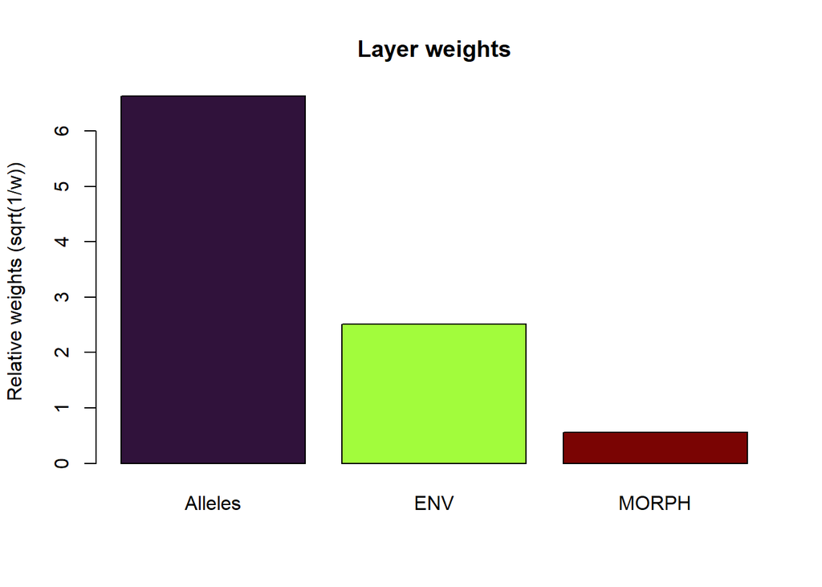

```r
plot.Layers.SOM(SOM_Alleles_ENV_MORPH)
```

##### Evaluate K-values

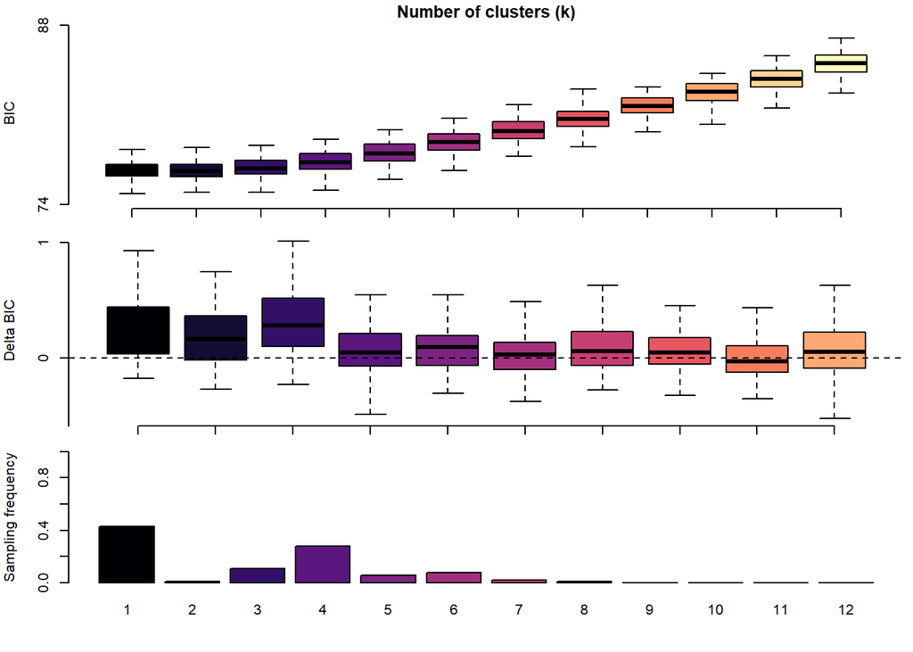

```r
plot.K.SOM(SOM_Alleles)
```

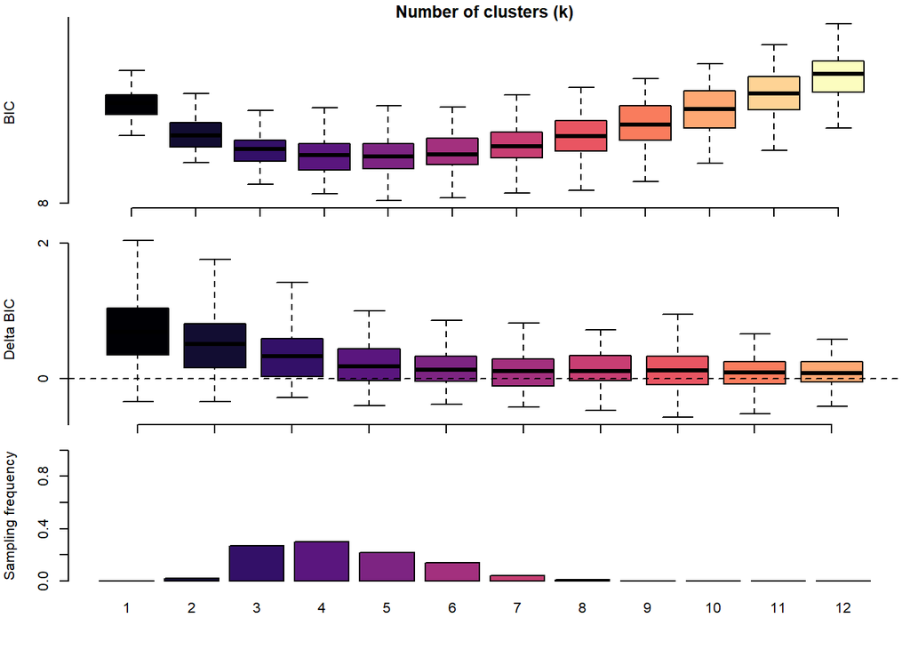

```r
plot.K.SOM(SOM_ENV)
```

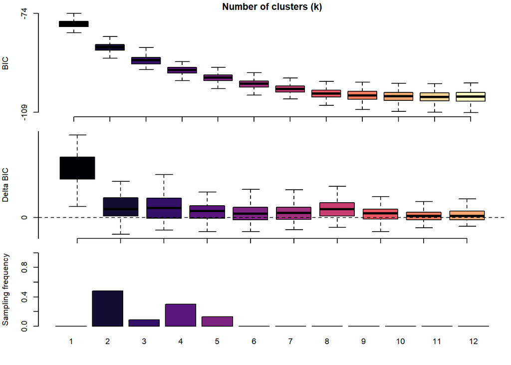

```r
plot.K.SOM(SOM_MORPH)
```

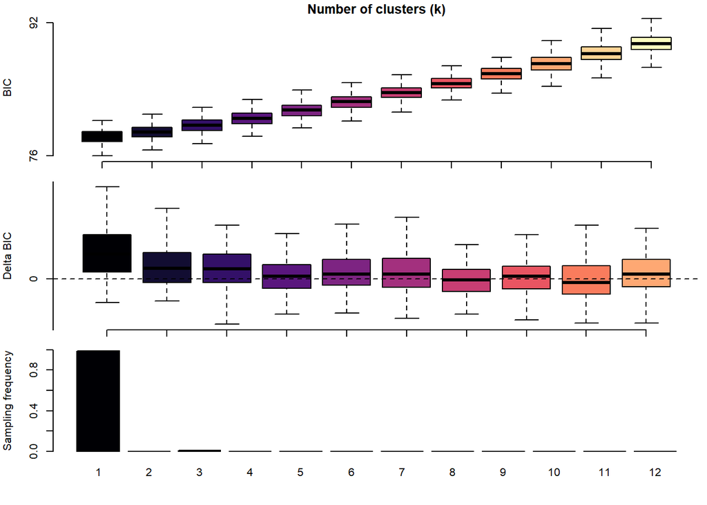

```r
plot.K.SOM(SOM_Alleles_ENV_MORPH)
```

##### Get and synchronize labels for different K values and summarize across K for Qmat

```r
SOM_Alleles <- match.k.and.labels.SOM(SOM_Alleles)
SOM_ENV <- match.k.and.labels.SOM(SOM_ENV)
SOM_MORPH <- match.k.and.labels.SOM(SOM_MORPH)
SOM_Alleles_ENV_MORPH <- match.k.and.labels.SOM(SOM_Alleles_ENV_MORPH)
```

##### Plot model results as SOM grids (showing sample assignment to cells, cell distances and boundaries between cell clusters, with each cell being occupied by zero to n individuals)

```
## Inferred number of clusters (K): 1
```

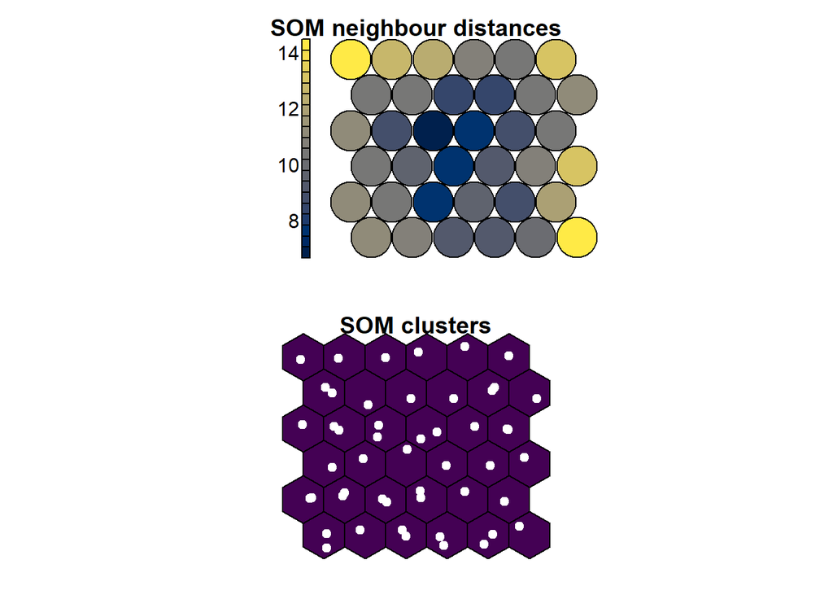

```r
plot.Model.SOM(SOM_Alleles)
```

```
## Inferred number of clusters (K): 4
```

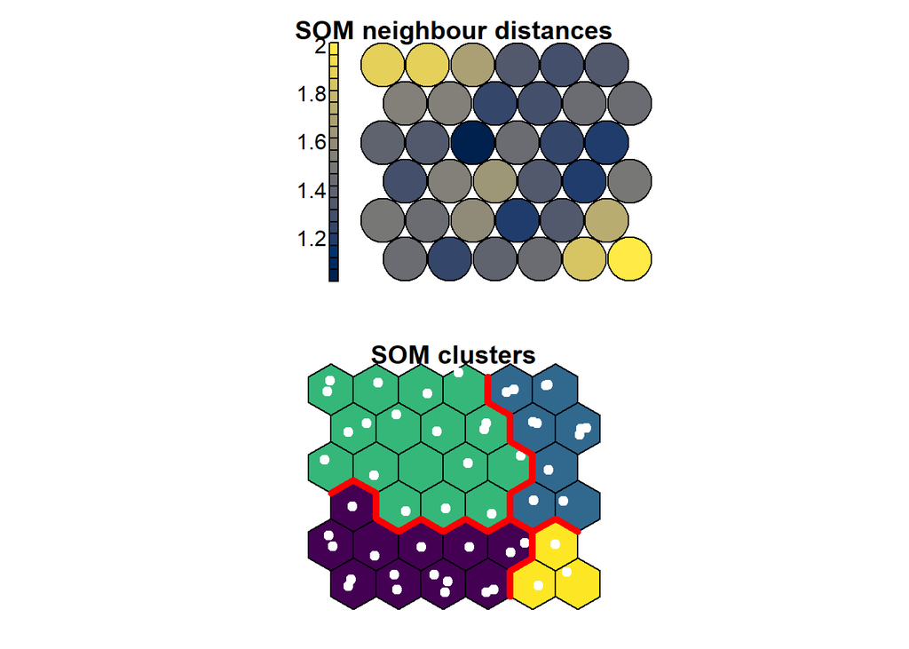

```r
plot.Model.SOM(SOM_ENV)
```

```
## Inferred number of clusters (K): 2
```

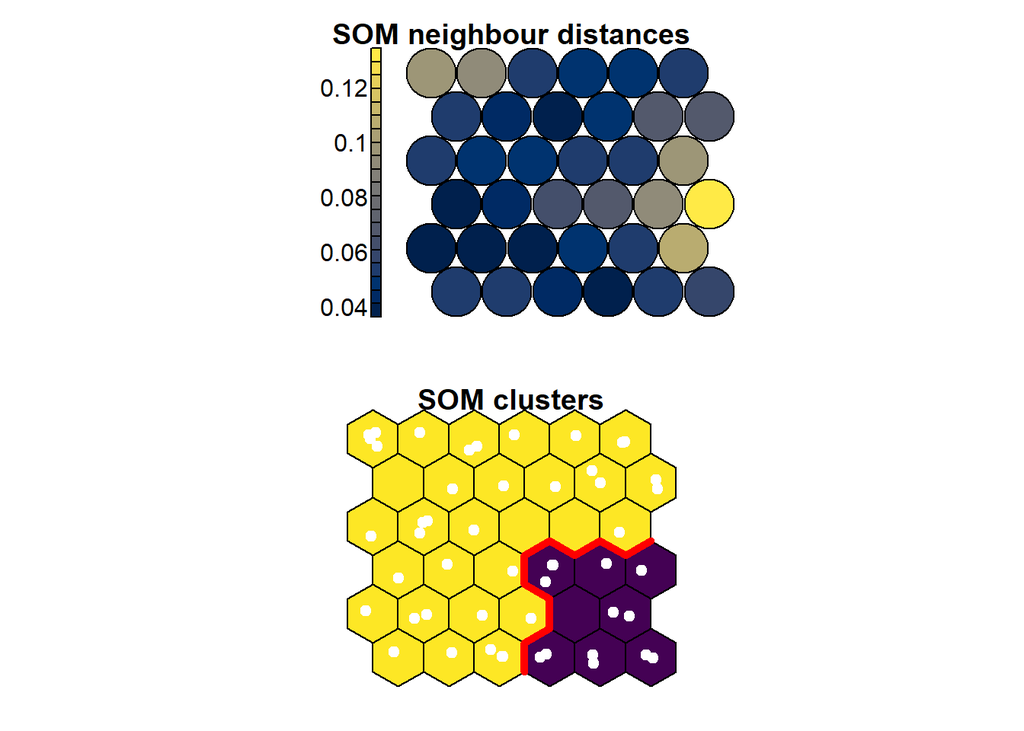

```r
plot.Model.SOM(SOM_MORPH)
```

```
## Inferred number of clusters (K): 1
```

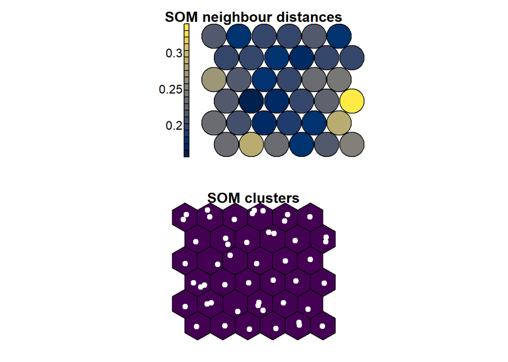

```r
plot.Model.SOM(SOM_Alleles_ENV_MORPH)
```

##### Plot Structure-like barplots and save admixture proportions as csv file

```
## SOM admixture proportions overwritten and saved to SOM_alleles_admixture.csv
```

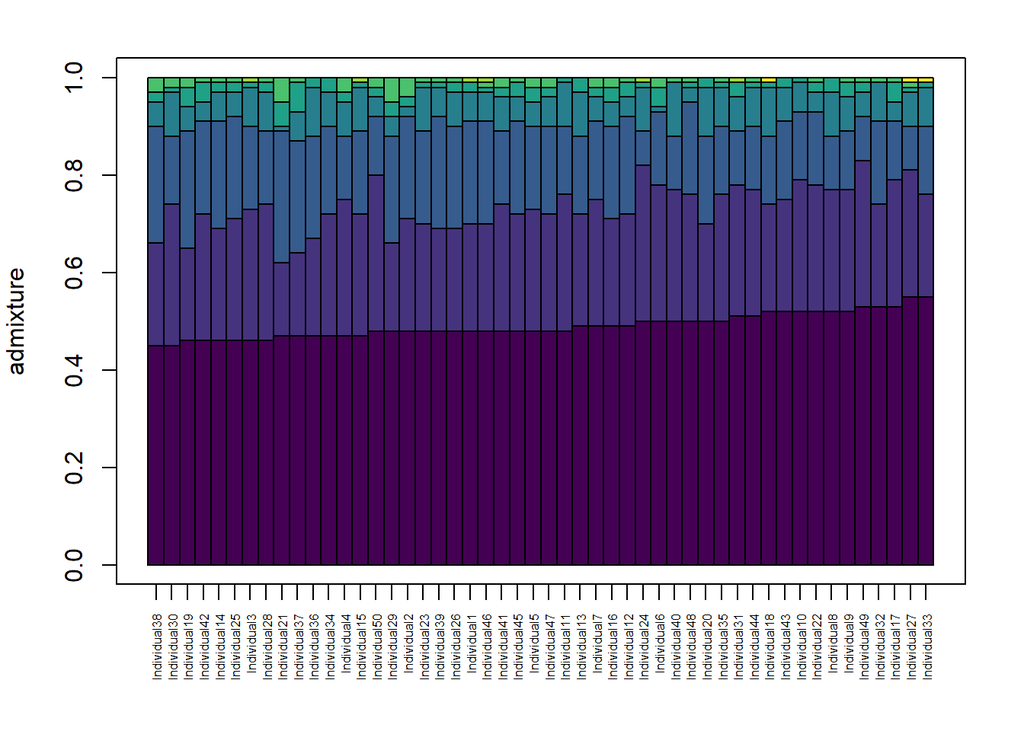

```r
plot.structure.SOM(SOM_Alleles, csv_filename_admixture_proportions = "SOM_alleles_admixture.csv", margin_bottom = 5)
```

```
## SOM admixture proportions overwritten and saved to SOM_ENV_admixture.csv
```

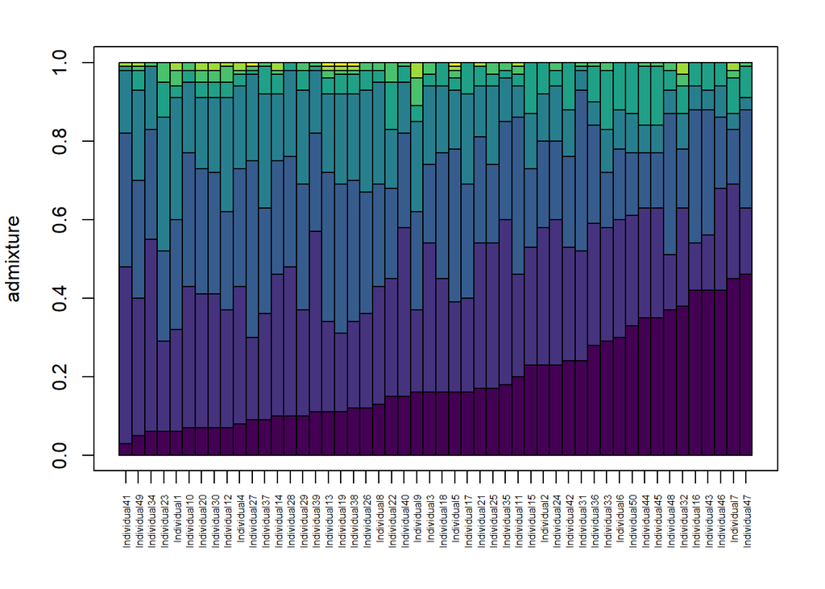

```r
plot.structure.SOM(SOM_ENV, csv_filename_admixture_proportions = "SOM_ENV_admixture.csv", margin_bottom = 5)
```

```
## SOM admixture proportions saved to SOM_MORPH_admixture.csv
```

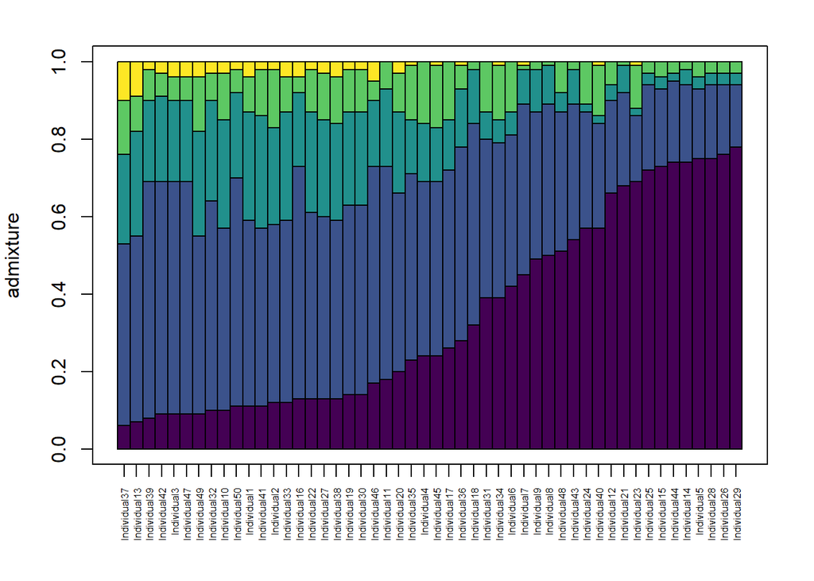

```r
plot.structure.SOM(SOM_MORPH, csv_filename_admixture_proportions = "SOM_MORPH_admixture.csv", margin_bottom = 5)
```

```
## SOM admixture proportions overwritten and saved to SOM_Alleles_ENV_MORPH_admixture.csv
```

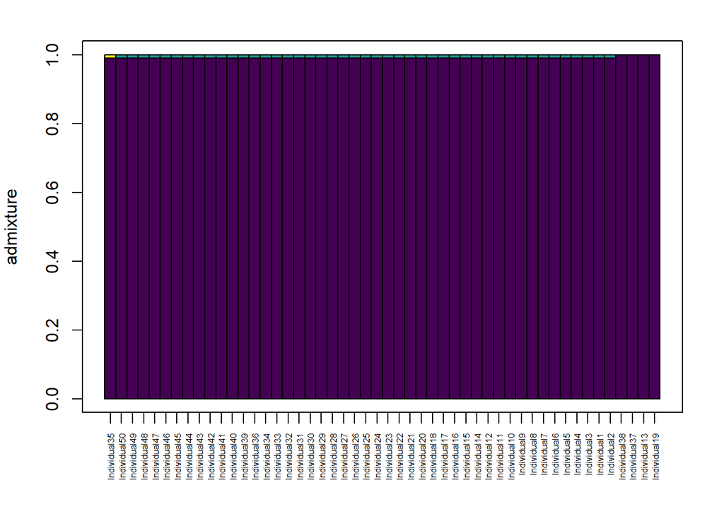

```r
plot.structure.SOM(SOM_Alleles_ENV_MORPH, csv_filename_admixture_proportions = "SOM_Alleles_ENV_MORPH_admixture.csv", margin_bottom = 5)
```

##### Plot variable importance for each matrix (based on Codebook Vectors/Neuron Weights)

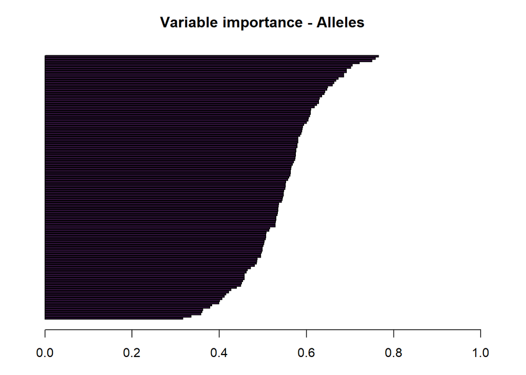

```r
variable.importance.SOM(SOM_Alleles)
```

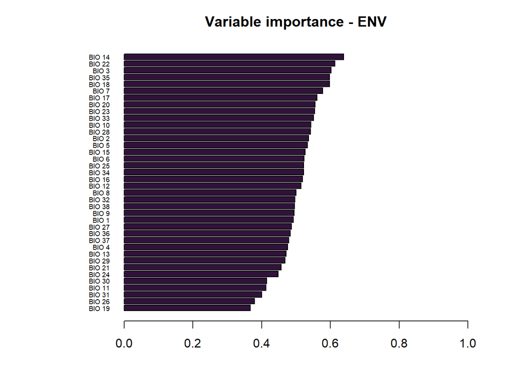

```r
variable.importance.SOM(SOM_ENV)
```

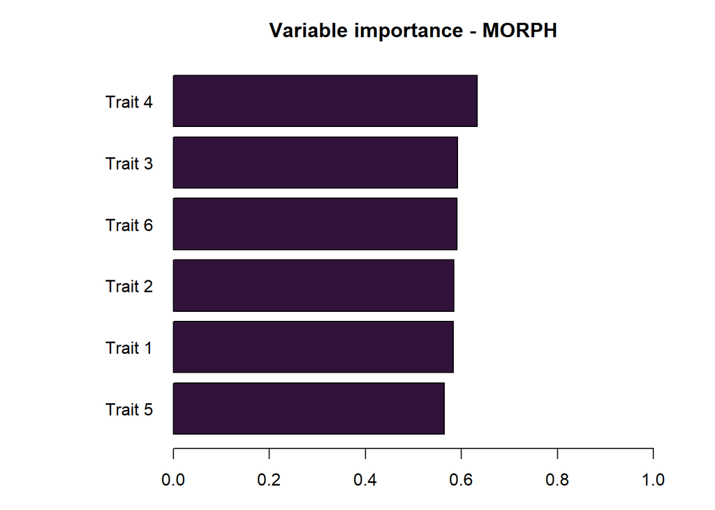

```r
variable.importance.SOM(SOM_MORPH)
```

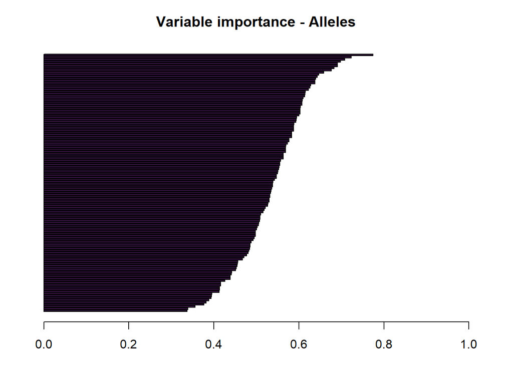

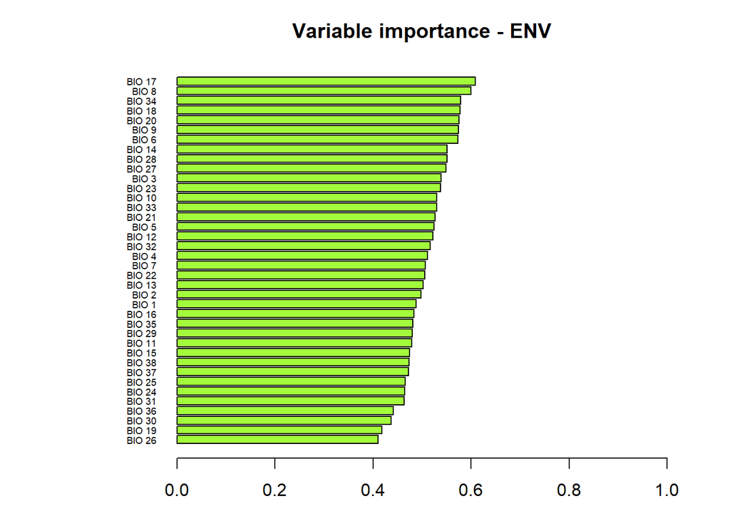

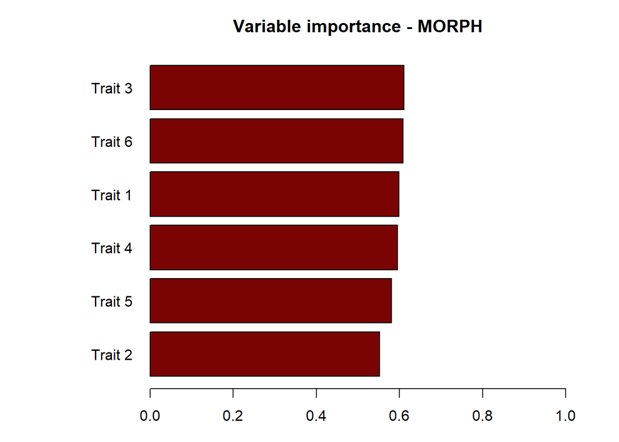

```r
variable.importance.SOM(SOM_Alleles_ENV_MORPH)
```